# Objects: the connectors among modules

Tati Micheletti

21 January 2020

`Objects` is the last topic to consider before starting a simulation. It is necessary to pass any objects you might want to override from the defaults. One example is the study area. You can load a shapefile in R, and pass it in the form `objects <- list(studyArea = shapefile)`. The names of all objects passed need to match the names these have defined in the modules. Objects, like parameters, can be found in the metadata of each module, in the sections `inputObjects` and `outputObjects`.

It is interesting to note that while **objects are shared** accross modules, **parameters are not**. The modules are in fact integrated by the objects these use as *inputs* and objects these produce as *outputs*. These also have to be defined in the metadata.

Module developers should provide default values for all parameters and objetcs, even if the objects are expected as inputs. This can be done in the section `.inputObjects <- function(sim){(...)}` of a module. This guarantees that anyone running your module, even without any data, is capable of seeing it work.

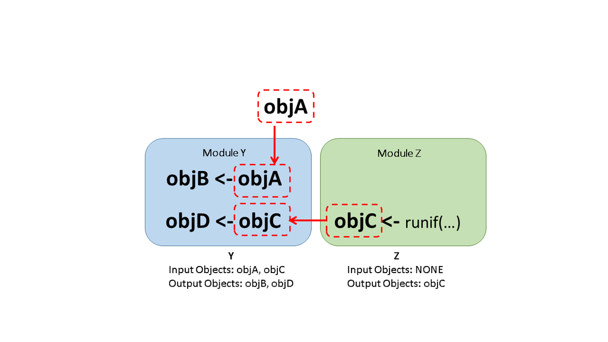

**Inputs and outputs in `SpaDES`:** Object A comes from outside of the module (e.g. from an internet URL, from data you have, etc), while Module Z produces object C. Both objects serve as an **inputs** for Module Y, which in return produce as **outputs** objects B and D, respectivelly from objects A and C. As Module Z uses a simple function “internally” to create object C, it doesn’t have any inputs, such as our dummy example.

One of the most amazing features of SpaDES is the “on-the-fly” calibration of parameters for statistical models. It does it using a data-driven approach. Still, it does take some time and depending on the data, it needs connection to the internet to download it. If you want to avoid connecting to the internet to download data, we have saved a few objects that can be passed in the simulation:

```r
flammableMap <- readRDS(file.path(getPaths()$inputPath, "flammableMap.rds"))
landscapeAttr <- readRDS(file.path(getPaths()$inputPath, "landscapeAttr.rds"))
scfmDriverPars <- readRDS(file.path(getPaths()$inputPath, "scfmDriverPars.rds"))
scfmRegimePars <- readRDS(file.path(getPaths()$inputPath, "scfmRegimePars.rds"))
firePoints <- readRDS(file.path(getPaths()$inputPath, "firePoints.rds"))
sppEquivalenciesTable <- readRDS(file.path(getPaths()$inputPath, "sppEquivalenciesTable.rds"))
```